# Code to reproduce the analyses of the AWST paper: Analysis of the LGG data

[S.M.Pagnotta](https://www.researchgate.net/profile/Stefano_Pagnotta) - Dept. of Science and Technology, Universita’ degli Studi del Sannio (Benevento, Italy) [D.Risso](https://www.researchgate.net/profile/Davide_Risso) - Dept. of Statistical Sciences, Universita’ degli Studi di Padova (Padova, Italy)

compiled on January 29, 2020

Here we show the code to reproduce the analyses of: Risso and Pagnotta (2019). Within-sample standardization and asymmetric winsorization lead to accurate classification of RNA-seq expression profiles. In preparation.

This file belongs to the repository: https://github.com/drisso/awst_analysis.

The code is released with license GPL v3.0.

# Install and load `awst`

```r
if (!requireNamespace("BiocManager", quietly = TRUE))
    install.packages("BiocManager")

BiocManager::install("drisso/awst")
```

# Data import and cleaning

For this analysis, we used the collection of 516 samples from the TCGA legacy repository, specifically the RSEM estimates of 20{,}531 gene expressions.

The level-3 LGG data are available in the [Genomic Data Commons Data Portal](https://portal.gdc.cancer.gov). The data are also available through the R/Bioconductor packages [`curatedTCGAData`](https://www.bioconductor.org/packages/curatedTCGAData) and [`TCGABiolinks`](https://www.bioconductor.org/packages/TCGAbiolinks).

For simplicity, we have included the data in this repository as an `.RData` file.

We also include a tab-delimited file with some gene info useful for the GC-content normalization performed here.

# Figure 4: the clustering

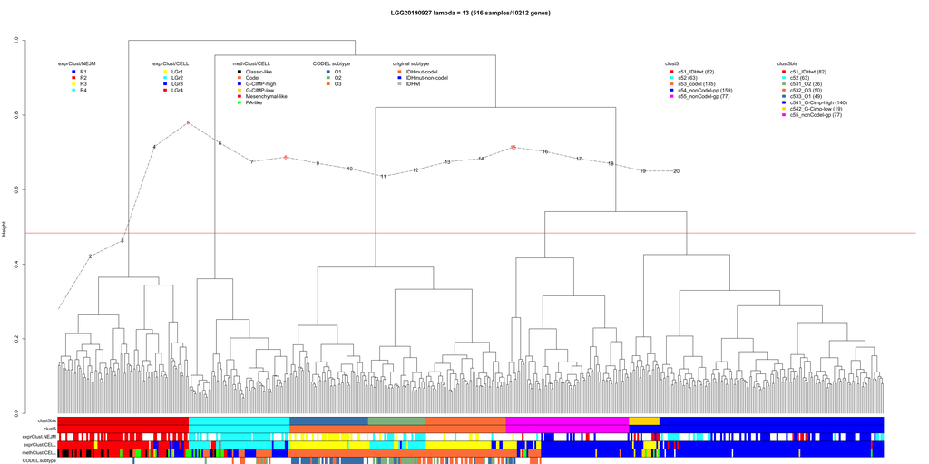

# Supplementary Figure 4: clustering on the residual features

Hierarchical clustering of the 516 LGG samples with the Ward’s linkage method from an Euclidean matrix involving 8,926 features having heterogeneity less than 0.10.

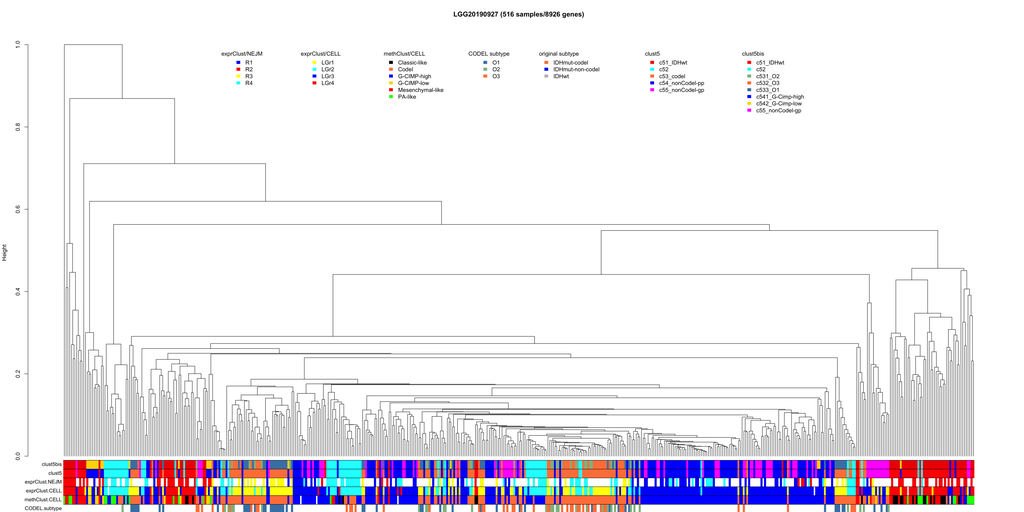

# Supplementary Figure 5

Kaplan-Meyer estimates of the survival curves associated with clust5 partition, based on the overall survival time. The log-rank test returns p-value $\leq 2.2 \cdot 10^{-16}$.

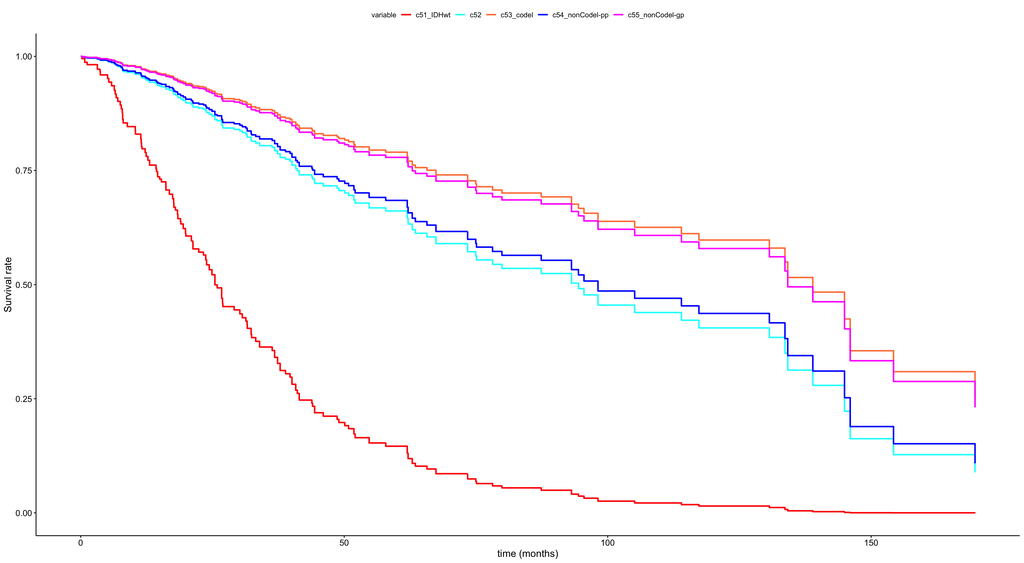

```
## Call:
## survdiff(formula = Surv(tmp.df$surv_time, tmp.df$surv_status) ~
##     clust5.explanatory, data = tmp.df)
##
##                   N Observed Expected (O-E)^2/E (O-E)^2/V
## c51_IDHwt        82       45     11.2   101.732   114.064
## c52              63       13     14.3     0.125     0.142
## c53_codel       134       19     35.9     7.933    11.241
## c54_nonCodel-pp 158       38     45.0     1.102     1.733
## c55_nonCodel-gp  77       10     18.5     3.929     4.651
##
##  Chisq= 117  on 4 degrees of freedom, p= <2e-16
```

# Supplementary Figure 6

Kaplan-Meyer estimates of the survival curves associated with the two non-codel subsets c54 and c55, based on the overall survival time. The log-rank test returns p-value = $0.2$.

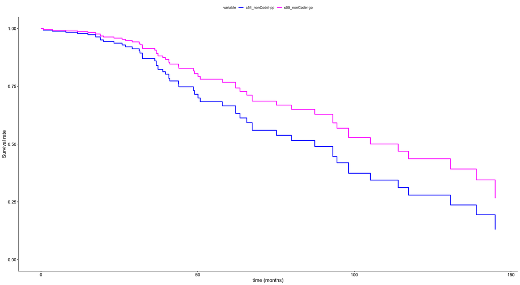

```
## Call:
## survdiff(formula = Surv(tmp.df$surv_time, tmp.df$surv_status) ~
##     clust5.explanatory, data = tmp.df)
##
##                   N Observed Expected (O-E)^2/E (O-E)^2/V
## c54_nonCodel-pp 158       38     34.2     0.417      1.48
## c55_nonCodel-gp  77       10     13.8     1.036      1.48
##
##  Chisq= 1.5  on 1 degrees of freedom, p= 0.2
```

# Supplementary Figure 7

Kaplan-Meyer estimates of the survival curves associated with the subsets c533/O1, c531/O2, and c532/O3 (Kamoun and others, 2016) in c53 (IDHmut-CODELS), based on the overall survival time. The log-rank test returns p-value = 0.02.

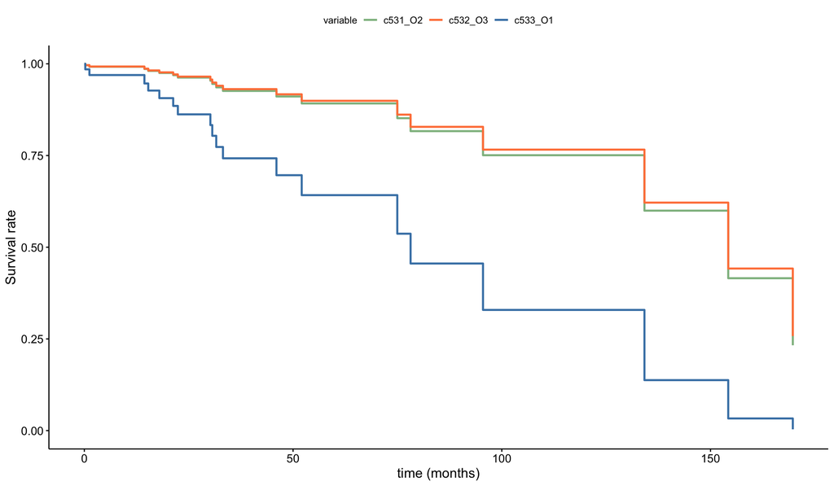

```
## Call:
## survdiff(formula = Surv(tmp.df$surv_time, tmp.df$surv_status) ~
##     clust5bis.explanatory, data = tmp.df)
##
##          N Observed Expected (O-E)^2/E (O-E)^2/V
## c531_O2 36        5     7.32     0.737      1.27
## c532_O3 50        4     6.66     1.064      1.66
## c533_O1 48       10     5.01     4.958      7.39
##
##  Chisq= 7.4  on 2 degrees of freedom, p= 0.02
```

# Supplementary Figure 8

Kaplan-Meyer estimates of the survival curves associated with the two subsets c541 (G-Cimp-High) ant c542 (G-Cimp-Low), based on the overall survival time. The log-rank test returns p-value = $2\cdot 10^{-4}$.

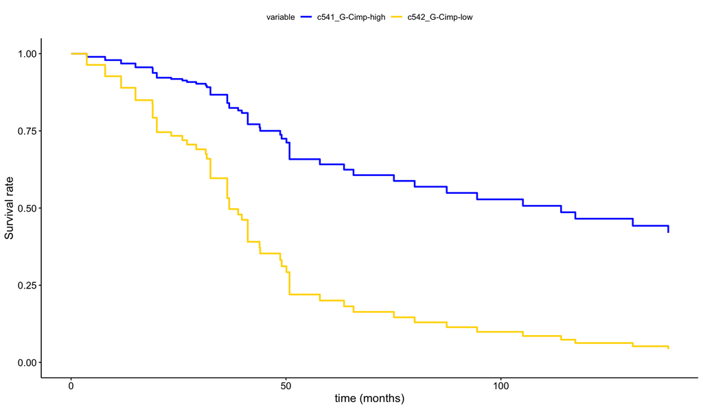

```
## Call:
## survdiff(formula = Surv(tmp.df$surv_time, tmp.df$surv_status) ~
##     clust5bis.explanatory, data = tmp.df)
##
##                    N Observed Expected (O-E)^2/E (O-E)^2/V
## c541_G-Cimp-high 139       28    34.59      1.25      14.3
## c542_G-Cimp-low   19       10     3.41     12.72      14.3
##
##  Chisq= 14.3  on 1 degrees of freedom, p= 2e-04
```

# Supplementary Figure 9

Kaplan-Meyer estimates of the survival curves associated with clust5bis partition, based on the overall survival time. The log-rank test returns p-value $\leq 2.2\cdot 10^{-16}$.

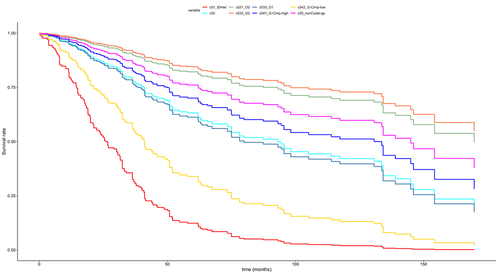

```
## Call:
## survdiff(formula = Surv(tmp.df$surv_time, tmp.df$surv_status) ~
##     clust5bis.explanatory, data = tmp.df)
##
##                    N Observed Expected (O-E)^2/E (O-E)^2/V
## c51_IDHwt         82       45    11.22  1.02e+02  1.14e+02
## c52               63       13    14.34  1.25e-01  1.42e-01
## c531_O2           36        5    13.24  5.13e+00  5.89e+00
## c532_O3           50        4    12.41  5.70e+00  6.37e+00
## c533_O1           48       10    10.21  4.34e-03  4.77e-03
## c541_G-Cimp-high 139       28    40.13  3.67e+00  5.44e+00
## c542_G-Cimp-low   19       10     4.91  5.27e+00  5.61e+00
## c55_nonCodel-gp   77       10    18.53  3.93e+00  4.65e+00
##
##  Chisq= 128  on 7 degrees of freedom, p= <2e-16
```